# Evaluating Models

Andrew Engellant

2024-04-29

```r
# load libraries
library(tidymodels)
```

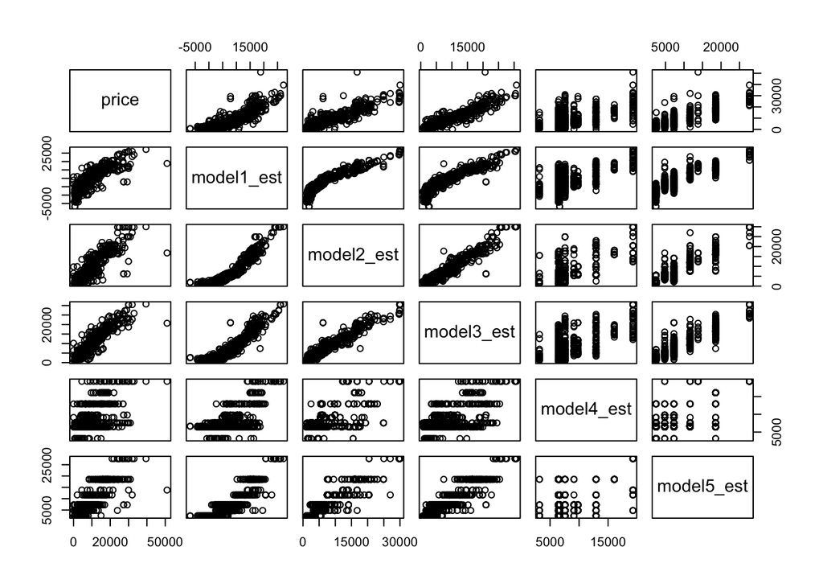

```r
# read data
d <- read.table('training_price_estimates.txt', sep='\t',header = TRUE)
d2 <- read.table('price_estimates.txt', sep = '\t', header = TRUE)
# view plots of price vs each model
pairs(d)
```

The above plots give an initial insight into the performance of each model. By observing the top row of scatter plots, the predictions from each model can be seen plotted again the actual price. Models 1 and 2 both appear to have several outliers from under-predictions. Model 3 has less obvious outliers, and models 4 and 5 both appear to be tree models. Let’s calculate some statistics to better evaluate each model’s performance.

```r
example.set <- metric_set(rsq, rmse, mae, mape, huber_loss)


example.set(d2, truth = price, estimate = model1_est) %>%
  select(-.estimator) %>%
  rename(model1 = .estimate) %>%
  left_join(
    example.set(d2, truth = price, estimate = model2_est) %>%
      select(-.estimator) %>%
      rename(model2 = .estimate),
    by = ".metric"
  ) %>%
  left_join(
    example.set(d2, truth = price, estimate = model3_est) %>%
      select(-.estimator) %>%
      rename(model3 = .estimate),
    by = ".metric"
  ) %>%
  left_join(
    example.set(d2, truth = price, estimate = model4_est) %>%
      select(-.estimator) %>%
      rename(model4 = .estimate),
    by = ".metric"
  ) %>%
  left_join(
    example.set(d2, truth = price, estimate = model5_est) %>%
      select(-.estimator) %>%
      rename(model5 = .estimate),
    by = ".metric"
  )
```

```
## # A tibble: 5 × 6
##   .metric      model1   model2   model3   model4   model5
##   <chr>         <dbl>    <dbl>    <dbl>    <dbl>    <dbl>
## 1 rsq           0.729    0.795    0.870    0.332    0.694
## 2 rmse       3476.    3042.    2415.    5501.    3690.
## 3 mae        2333.    1835.    1478.    4111.    2413.
## 4 mape       3034.    2455.    2359.    3368.    2253.
## 5 huber_loss 2333.    1834.    1478.    4111.    2412.
```

By assessing each model’s $R^2$, root mean square error, mean absolute error, and mean absolute percentage error, model 3 appears to do the best job predicting price. Model 3 has a higher $R^2$ and lower RMSE and MAE compared to the other four models. Only model 5 has a lower MAPE than model 3, indicating model 5 might perform better when predicting the price of inexpensive Subarus, however these statistics are comparable in size. Since RMSE squares each residual, a disproportionately greater penalty is assigned to larger residuals. MAE on the other hand does not the square residuals and therefore assigns a more linear and equal penalty to different sizes of residuals. I’ve included another metric called the Huber Loss. The Huber Loss uses a mixture of these two approaches, weighing only smaller residuals as their square. This results in a metric that is more robust to outliers since it assigns more weight to smaller residuals. Model 3 again has the smallest Huber Loss.

Ultimately, Models 3 appears to do the best job predicting the price of Subarus. Model 2 does the second best job. If the user cared mostly about the model’s ability to accurately predict the price of less expensive cars, model 5 should be considered.

Let’s take a closer look at models 2 and 3 to assess where their weaknesses are.

```r
# Add residuals to d
d2$m3_residuals <- d2$model3_est - d2$price
d2$m2_residuals <- d2$model2_est - d2$price

table(d2$model)
```

```
##
##            brz       forester    forester-xt        impreza    impreza-wrx
##             26            217             39            108             36
##         legacy legacy-outback        outback        sti-wrx            wrx
##            138             22            198             33             63
```

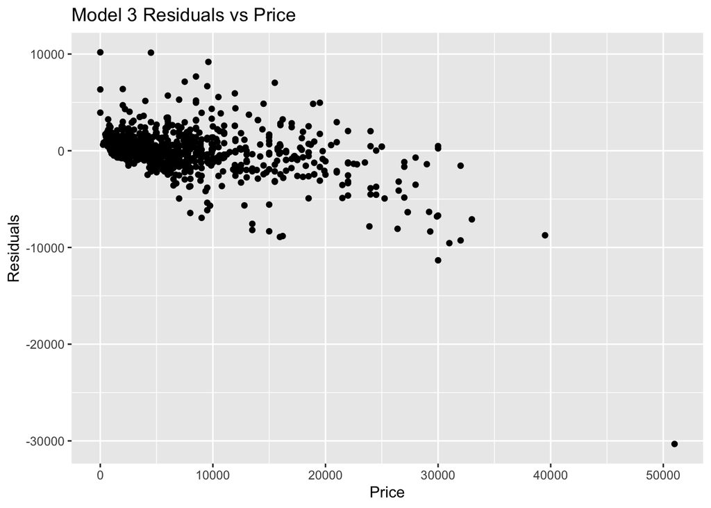

```r
d3 <- d2 %>%
  filter(model %in% c('forester','outback','legacy','impreza'))

# plot residuals
ggplot(d2, aes(x = price, y = m3_residuals)) +
  geom_point() +
  labs(x = "Price", y = "Residuals", title = "Model 3 Residuals vs Price")
```

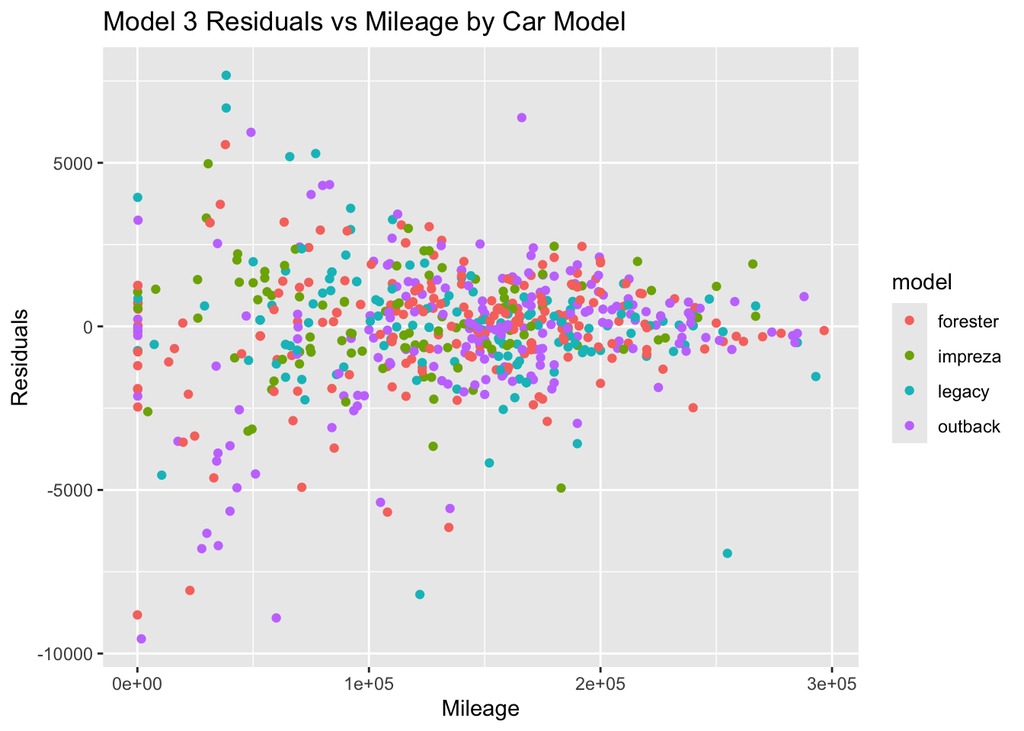

```r
ggplot(d3, aes(x = odometer, y = m3_residuals, col = model)) +
  geom_point() +
  labs(x = "Mileage", y = "Residuals", title = "Model 3 Residuals vs Mileage by Car Model")
```

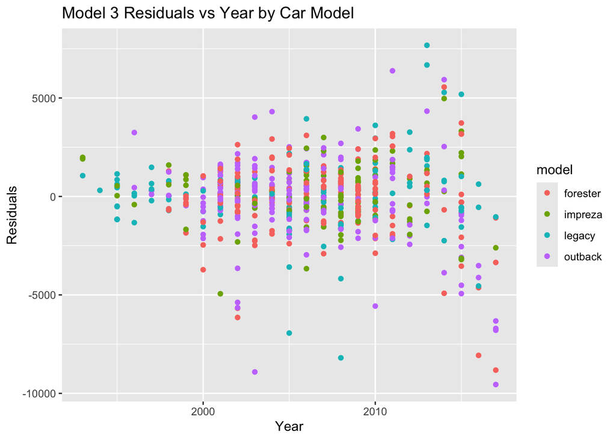

```r
ggplot(d3, aes(x = year, y = m3_residuals, col = model)) +
  geom_point() +
  labs(x = "Year", y = "Residuals", title = "Model 3 Residuals vs Year by Car Model")
```

The first graph above compares Model 3’s prediction residuals to the actual price of each Subaru. The model overall does a good job as most of the points are banded around 0. The overall downward trend indicates that the model generally tends to over-predicts the price of less expensive cars and under-predicts the price of more expensive cars. There are also a few unusual outliers. The model under-predicted the price of a $50,000 car by $30,000, and the model over-predicted a car that was was listed for close to $0 by $10,000. The first outlier has the potential to significantly impact RMSE, and the second outlier could have a large impact on MAPE.

The second two graphs compare Model 3’s residuals to the Mileage and Year variables using a filtered dataset that only includes the top four car models (Forester, Impreza, Legacy and Outback). These two graphs also distinguish between car models using color. Generally, Model 3 does a good job predicting the price of car with zero miles and greater than 100,000 miles. For cars greater than 0 and less than 100,000 miles, this model has much greater variation in prediction residuals. For these low mileage cars, the model tends to underestimate the price of Outbacks and Foresters, and over-predict the price of Legacies.

When it comes to Year, This model does a fine job predicting the price of cars older than 2000. For 2000 to 2012 cars, this model also does a decent job, although it under-predicted the price of several Outback and Legacy cars by more than $5,000. This model struggles the most with newer cars. For cars newer than 2012, this model has much higher variation in prediction residuals, and consistently under-predicts the price of cars from 2016 and 2017.

Let’s look at where Model 2’s weaknesses lie.

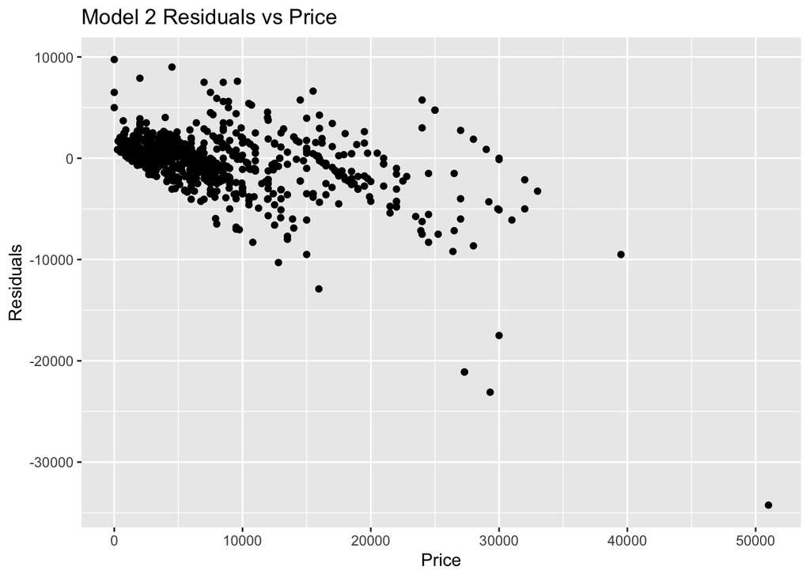

```r
# plot residuals for Model 2
ggplot(d2, aes(x = price, y = m2_residuals)) +
  geom_point() +
  labs(x = "Price", y = "Residuals", title = "Model 2 Residuals vs Price")
```

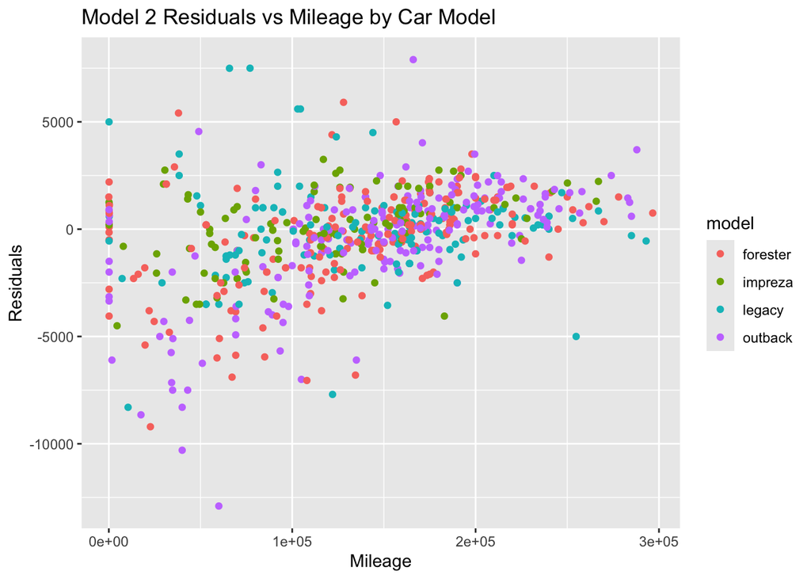

```r
ggplot(d3, aes(x = odometer, y = m2_residuals, col = model)) +
  geom_point() +
  labs(x = "Mileage", y = "Residuals", title = "Model 2 Residuals vs Mileage by Car Model")
```

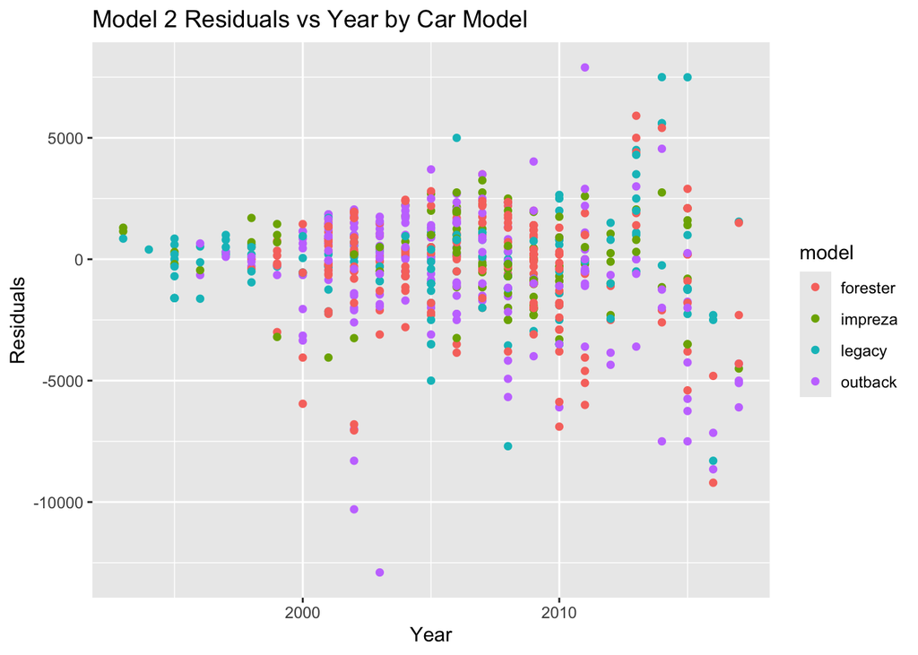

```r
ggplot(d3, aes(x = year, y = m2_residuals, col = model)) +
  geom_point() +
  labs(x = "Year", y = "Residuals", title = "Model 2 Residuals vs Year by Car Model")
```